# TCAC 2.0 — Vectorisation Report

SPECTER2 embeddings, keypaper-similarity scoring

Author

Rainer M. Krug

Published

June 29, 2026

[figure not shown]

Part of the Data Management Report

[figure not shown]

# Contributors of the original TCAC 1.0

## Assessment Experts

- Shannon, Lynne
- Liao, Chuan
- Zinngrebe, Yves

[figure not shown]

- Frantzeskaki, Niki

[figure not shown]

- Gurung, Janita

[figure not shown]

- Leventon, Julia

[figure not shown]

- Wickson, Fern
- Biggs, Oonsie
- Bennett, Elena
- Calderón-Contreras, Rafael

[figure not shown]

- Gosnell, Hannah
- Cantu Fernandez, Mariana
- Carr, Edward

[figure not shown]

- Benessaiah, Karina

[figure not shown]

## Data and Knowledge tsu

- Niamir, Aidin

[figure not shown]

- Gudde, Renske

[figure not shown]

# Working Title

TCAC 2.0 — Transformative Change Assessment Corpus 2.0

## Code repo

[Github repository](https://github.com/IPBES-Data/TCAC-2.0)

# Introduction

The literature search for the Transformative Change assessment corpus was conducted using search terms provided by the experts and refined in co-operation with the IPBES task force for data and knowledge management. The search was conducted using [OpenAlex](https://openalex.org), scripted from [R](https://cran.r-project.org) to use the [OpenAlex API](https://docs.openalex.org). Search terms for the following searches were defined:

- **Transformative Change**,
- **Nature / Environment**
- **case studies** and
- **additional search terms** for specific corpora

To assess the quality of the corpus, sets of key papers were selected by the experts to verify if these are in the corpus. These key papers were selected per chapter / sub-chapter to ensure that the corpus is representative of each chapter.

The following terminology is used in this document:

- **Corpus**: A body of works as based on a search on [OpenAlex](https://openalex.org)
- **Transformative Change Assessment Corpus**: Short: TCA corpus; The corpus resulting from the search terms `transformative AND nature`
- **Case corpus**: The corpus resulting from `transformative AND nature AND case`
- **work**: terminology used for a single document in their datasewt. Each work has a unique OpenAlex id, but not necesarily a DOI.

The following searches are conducted on Title and Abstract only as the availability of fulltexts drops in 2020. OpenAlex “inherited” their initial corpus from Microsoft Academic, which contained a many fulltext articles. After that initial start, other sources were used which did not all include fulltext versions. To eliminate a bias towards fulltext articles, we limited the search to abstracts and titles only.

## Schematic Overview

*TODO — replace with a TCAC 2.0 pipeline diagram. The original PlantUML source lived under `tca_corpus/input/tca_corpus.plantuml` in TCAC 1.0; nothing equivalent exists in this repository yet.*

## Search Terms

Here are the search terms used in this document. They were provided by the authors, and some adaptations were done by the tsu for data and knowledge management to adapt them to be suitable for a search in OpenAlex.

### Transformative Change

```r
cat(tar_read(tfc_st))
```

```
(
    (
        (
            transformation
            OR transition
            OR transformative
        )
        OR (
            (
                shift
                OR change
            )
            AND (
                fundamental
                OR deep
                OR radical
            )
        )
    )
    AND (
        socio
        OR business
        OR cultural
        OR economic
        OR financial
        OR governance
        OR inner
        OR personal
        OR political
        OR politics
        OR social
        OR system
        OR technological
    )
)
OR (
    (
        "transformative change"
        OR "complete change"
        OR "complete transformation"
```

[output cut: 43 more lines]

```
        OR transition
        OR value
        OR views
        OR widespread
    )
    AND (
        transformation
        OR action
        OR alteration
        OR change
        OR shift
        OR transition
        OR turn
    )
)
```

### Nature

```r
cat(tar_read(nature_st))
```

```
biodiversity
OR "agricultural land"
OR "agro-forest"
OR "arable land"
OR "coastal waters"
OR "coupled system"
OR "environmental resource"
OR "natural environment"
OR "natural resource"
OR "protected areas"
OR "resource system"
OR "socio-ecological"
OR agroforest
OR bioeconomy
OR biosphere
OR bog
OR chaparral
OR coast
OR conservation
OR desert
OR dryland
OR Earth
OR ecological
OR ecosystem
OR environment
OR estuary
OR fauna
OR fjord
OR flora
OR forest
OR freshwater
OR grassland
OR heathland
OR lake
OR landscape
OR marine
OR marshes
OR marshland
OR meadow
OR mires
OR mountain
OR nature
OR ocean
OR peatland
OR planet
OR plantation
OR restoration
OR river
OR savanna
OR sea
OR seascape
OR shrubland
OR soil
OR species
OR sustainable
OR terrestrial
OR tundra
OR wetland
OR wildlife
OR woodland
```

### Assessment Corpus

The combined `(nature) AND (transformative change)` query passed to OpenAlex:

```r
cat(tar_read(tca_st))
```

```
(
biodiversity
OR "agricultural land"
OR "agro-forest"
OR "arable land"
OR "coastal waters"
OR "coupled system"
OR "environmental resource"
OR "natural environment"
OR "natural resource"
OR "protected areas"
OR "resource system"
OR "socio-ecological"
OR agroforest
OR bioeconomy
OR biosphere
OR bog
OR chaparral
OR coast
OR conservation
OR desert
OR dryland
OR Earth
OR ecological
OR ecosystem
OR environment
OR estuary
OR fauna
OR fjord
OR flora
OR forest
OR freshwater
OR grassland
OR heathland
OR lake
OR landscape
OR marine
OR marshes
OR marshland
OR meadow
```

[output cut: 108 more lines]

```
        OR value
        OR views
        OR widespread
    )
    AND (
        transformation
        OR action
        OR alteration
        OR change
        OR shift
        OR transition
        OR turn
    )
)
)
```

# Results

## Assessment of Search Terms Using OpenAlex

### Number of Hits per Individual Corpus

Number of works returned by each individual search-term query and by the combined `(nature) AND (transformative change)` query, before and after the OpenAlex work-type filter is applied (only the types in `input/openalex_types.csv` with `Included = TRUE` are kept).

```r
cnt <- readRDS(tar_read(count_st))

# pro_request(count_only = TRUE) returns one row per query with `count`
# and `query`; the query column carries the named list element name.
labels <- c(
  tfc_complete = "Transformative Change — all types",
  tfc_filtered = "Transformative Change — filtered",
  nature_complete = "Nature — all types",
  nature_filtered = "Nature — filtered",
  tca_complete = "Assessment Corpus (combined) — all types",
  tca_filtered = "Assessment Corpus (combined) — filtered"
)

dplyr::tibble(
  search = labels[as.character(cnt$query)],
  count = as.integer(cnt$count)
) |>
  knitr::kable(
    format.args = list(big.mark = ","),
    caption = "Number of works matching each search on OpenAlex. *filtered* applies the work-type filter; *all types* does not."
  )
```

Number of works matching each search on OpenAlex. *filtered* applies the work-type filter; *all types* does not.

| search | count |
| --- | --- |
| Transformative Change — all types | 26,054,001 |
| Transformative Change — filtered | 24,497,631 |
| Nature — all types | 34,344,868 |
| Nature — filtered | 29,585,194 |
| Assessment Corpus (combined) — all types | 7,079,438 |
| Assessment Corpus (combined) — filtered | 6,584,913 |

The actual corpora extracted from the snapshot (after the type filter), compared with TCAC 1.0:

```r
tibble::tibble(
  corpus = c("TCAC 1.0", "TCAC 2.0"),
  `Works extracted` = c(cmp$n_tcac10, cmp$n_tcac20)
) |>
  knitr::kable(
    align = c("l", "r"),
    format.args = list(big.mark = ",")
  )
```

Table 1

| corpus | Works extracted |
| --- | --- |
| TCAC 1.0 | 4,178,134 |
| TCAC 2.0 | 5,771,209 |

## TCA Corpus properties

### Works per type

Per OpenAlex `type`, work count in each corpus and the difference (TCAC 2.0 minus TCAC 1.0). Sorted by TCAC 2.0 count. Negative diff (works lost) shown in red; positive (works gained) in green.

```r
cmp$type_counts |>
  dplyr::mutate(
    diff = ifelse(
      diff < 0,
      sprintf(
        "<span style='color:red'>%s</span>",
        format(diff, big.mark = ",")
      ),
      sprintf(
        "<span style='color:green'>+%s</span>",
        format(diff, big.mark = ",")
      )
    ),
    `tcac_1.0` = format(`tcac_1.0`, big.mark = ","),
    `tcac_2.0` = format(`tcac_2.0`, big.mark = ",")
  ) |>
  knitr::kable(
    format = "html",
    escape = FALSE,
    align = c("l", "r", "r", "r"),
    caption = "Works per type in each corpus."
  )
```

Table 2: Works per type in each corpus.

| type | tcac_1.0 | tcac_2.0 | diff |
| --- | --- | --- | --- |
| article | 3,316,535 | 4,570,182 | +1,253,647 |
| book-chapter | 239,516 | 487,459 | + 247,943 |
| preprint | 153,091 | 310,619 | + 157,528 |
| dissertation | 110,046 | 262,058 | + 152,012 |
| book | 55,500 | 102,953 | + 47,453 |
| report | 22,360 | 37,650 | + 15,290 |
| other | 18,859 | 264 | -18,595 |
| dataset | 12,962 | 10 | -12,952 |
| report-component | 0 | 6 | + 6 |
| paratext | 10,341 | 4 | -10,337 |
| peer-review | 33,774 | 2 | -33,772 |
| editorial | 23,734 | 1 | -23,733 |
| standard | 120 | 1 | -119 |
| erratum | 1,303 | 0 | -1,303 |
| grant | 1 | 0 | -1 |
| letter | 46,761 | 0 | -46,761 |
| libguides | 82 | 0 | -82 |
| reference-entry | 3,740 | 0 | -3,740 |
| retraction | 69 | 0 | -69 |
| review | 129,319 | 0 | -129,319 |
| supplementary-materials | 21 | 0 | -21 |

### Key papers in the corpus

Does the corpus actually cover the works the experts consider key? For each keypaper we check whether its OpenAlex id is present in TCAC 1.0 and / or in the new TCAC 2.0 extract.

#### Summary

```r
kp <- cmp$keypaper_presence
n_kp <- nrow(kp)
tibble::tibble(
  status = c("in corpus", "missing from corpus", "total keypapers"),
  `TCAC 1.0` = c(sum(kp$in_tcac10), sum(!kp$in_tcac10), n_kp),
  `% 1.0` = round(100 * c(mean(kp$in_tcac10), mean(!kp$in_tcac10), 1), 2),
  `TCAC 2.0` = c(sum(kp$in_tcac20), sum(!kp$in_tcac20), n_kp),
  `% 2.0` = round(100 * c(mean(kp$in_tcac20), mean(!kp$in_tcac20), 1), 2)
) |>
  knitr::kable(
    align = c("l", "r", "r", "r", "r"),
    format.args = list(big.mark = ","),
    caption = "Coverage of the keypaper set by each corpus."
  )
```

Coverage of the keypaper set by each corpus.

| status | TCAC 1.0 | % 1.0 | TCAC 2.0 | % 2.0 |
| --- | --- | --- | --- | --- |
| in corpus | 82 | 58.16 | 80 | 56.74 |
| missing from corpus | 59 | 41.84 | 61 | 43.26 |
| total keypapers | 141 | 100.00 | 141 | 100.00 |

#### Detail

Per-keypaper presence in TCAC 1.0 and TCAC 2.0. Sorted with “in both” rows at the top, then by citation. Rows flagged red are missing from that corpus — candidates for revisiting the search terms (or the keypaper itself, if it’s borderline off-topic).

```r
cmp$keypaper_presence |>
  dplyr::mutate(
    `TCAC 1.0` = ifelse(
      in_tcac10,
      "<span style='color:green'>✓</span>",
      "<span style='color:red'>✗</span>"
    ),
    `TCAC 2.0` = ifelse(
      in_tcac20,
      "<span style='color:green'>✓</span>",
      "<span style='color:red'>✗</span>"
    )
  ) |>
  dplyr::transmute(
    `TCAC 1.0`,
    `TCAC 2.0`,
    citation,
    title
  ) |>
  knitr::kable(
    format = "html",
    escape = FALSE,
    caption = "Keypaper presence in each corpus."
  )
```

Keypaper presence in each corpus.

| TCAC 1.0 | TCAC 2.0 | citation | title |
| --- | --- | --- | --- |
| ✓ | ✓ | Adeniyi Asiyanbi & Kate Massarella (2020) | Transformation is what you expect, models are what you get: REDD+ and models in conservation and development |
| ✓ | ✓ | Alice C. Hughes et al. (2022) | Smaller human populations are neither a necessary nor sufficient condition for biodiversity conservation |
| ✓ | ✓ | Andra‐Ioana Horcea‐Milcu et al. (2020) | Research pathways to foster transformation: linking sustainability science and social-ecological systems research |
| ✓ | ✓ | Andrea J. Nightingale et al. (2019) | Beyond Technical Fixes: climate solutions and the great derangement |
| ✓ | ✓ | Andrew Reid Bell et al. (2018) | Transformative change through Payments for Ecosystem Services (PES): a conceptual framework and application to conservation agriculture in Malawi |
| ✓ | ✓ | Anneleen Kenis et al. (2016) | Unravelling the (post-)political in Transition Management: Interrogating Pathways towards Sustainable Change |
| ✓ | ✓ | C Woiwode et al. (2021) | Inner transformation to sustainability as a deep leverage point: fostering new avenues for change through dialogue and reflection |
| ✓ | ✓ | Carina Wyborn et al. (2020) | Imagining transformative biodiversity futures |
| ✓ | ✓ | Carina Wyborn et al. (2020) | An agenda for research and action toward diverse and just futures for life on Earth |
| ✓ | ✓ | Christina Kelly et al. (2019) | Unravelling Persistent Problems to Transformative Marine Governance |
| ✓ | ✓ | Christine Wamsler & Gustav Osberg (2022) | Transformative climate policy mainstreaming – engaging the political and the personal |
| ✓ | ✓ | Christine Wamsler & Jamie Bristow (2022) | At the intersection of mind and climate change: integrating inner dimensions of climate change into policymaking and practice |
| ✓ | ✓ | Christine Wamsler (2020) | Education for sustainability |
| ✓ | ✓ | Christine Wamsler et al. (2017) | Mindfulness in sustainability science, practice, and teaching |
| ✓ | ✓ | Christine Wamsler et al. (2021) | Linking internal and external transformation for sustainability and climate action: Towards a new research and policy agenda |
| ✓ | ✓ | Christine Wamsler et al. (2022) | Rethinking political agency: The role of individuals’ engagement, perceptions and trust in transitioning to a low-carbon transport system |
| ✓ | ✓ | Christine Wamsler et al. (2022) | Meaning-making in a context of climate change: supporting agency and political engagement |
| ✓ | ✓ | Daniel Hausknost & Marit Hammond (2019) | Beyond the environmental state? The political prospects of a sustainability transformation |
| ✓ | ✓ | Daniel Hausknost (2019) | The environmental state and the glass ceiling of transformation |
| ✓ | ✓ | David J. Abson et al. (2016) | Leverage points for sustainability transformation |
| ✓ | ✓ | David Leclère et al. (2020) | Bending the curve of terrestrial biodiversity needs an integrated strategy |
| ✓ | ✓ | Derk Loorbach et al. (2017) | Sustainability Transitions Research: Transforming Science and Practice for Societal Change |
| ✓ | ✓ | Dominic Lenzi et al. (2023) | Justice, sustainability, and the diverse values of nature: why they matter for biodiversity conservation |
| ✓ | ✓ | Edward Mabaya & Jaron Porciello (2022) | Can digital solutions transform agri-food systems in Africa? |
| ✓ | ✓ | Eileen Crist et al. (2021) | Protecting Half the Planet and Transforming Human Systems Are Complementary Goals |
| ✓ | ✓ | Erik Hysing & Rolf Lidskog (2021) | Do Conceptual Innovations Facilitate Transformative Change? The Case of Biodiversity Governance |
| ✓ | ✓ | Esther Turnhout et al. (2021) | Enabling transformative economic change in the post‐2020 biodiversity agenda |
| ✓ | ✓ | Flor Avelino & Julia M. Wittmayer (2015) | Shifting Power Relations in Sustainability Transitions: A Multi-actor Perspective |
| ✓ | ✓ | Giuseppe Feola et al. (2021) | (Un)making in sustainability transformation beyond capitalism |
| ✓ | ✓ | Graciela M. Rusch et al. (2022) | A joint climate and nature cure: A transformative change perspective |

[output cut: 111 more lines]

### Publications over time

Bars: yearly count of works in the TCAC 2.0 corpus. Red line: cumulative proportion of the corpus. Blue line: cumulative proportion of *all* of OpenAlex over the same year range — a useful baseline for “is the corpus skewing recent vs the literature as a whole?”. Both cumulative lines use the secondary (right-hand) axis.

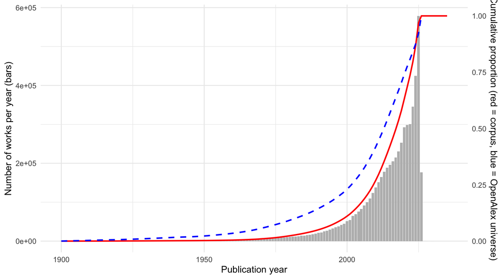

```r
years <- arrow::open_dataset(tar_read(corpus_tcac20)) |>
  dplyr::count(publication_year) |>
  dplyr::collect() |>
  dplyr::filter(!is.na(publication_year), publication_year >= 1900) |>
  dplyr::arrange(publication_year) |>
  dplyr::mutate(
    p = n / sum(n),
    p_cum = cumsum(p)
  )

# OpenAlex universe baseline (from yearly_counts target, label =
# "openalex_universe"). Recompute its cumulative proportion over the
# same year window as the corpus so the two lines are comparable.
oa_universe <- readRDS(tar_read(yearly_counts)) |>
  dplyr::filter(
    label == "openalex_universe",
    publication_year %in% years$publication_year
  ) |>
  dplyr::arrange(publication_year) |>
  dplyr::mutate(
    p_oa = count / sum(count),
    p_oa_cum = cumsum(p_oa)
  ) |>
  dplyr::select(publication_year, p_oa, p_oa_cum)

ymax <- max(years$n)

ggplot2::ggplot(years, ggplot2::aes(x = publication_year)) +
  ggplot2::geom_col(ggplot2::aes(y = n), fill = "#BBBBBB") +
  ggplot2::geom_line(
    ggplot2::aes(y = p_cum * ymax),
    colour = "red",
    linewidth = 0.9
  ) +
  ggplot2::geom_line(
    data = oa_universe,
    mapping = ggplot2::aes(y = p_oa_cum * ymax),
    colour = "blue",
    linewidth = 0.9,
    linetype = "dashed"
  ) +
  ggplot2::scale_y_continuous(
    name = "Number of works per year (bars)",
    sec.axis = ggplot2::sec_axis(
      ~ . / ymax,
      name = "Cumulative proportion (red = corpus, blue = OpenAlex universe)"
    )
  ) +
  ggplot2::labs(x = "Publication year") +
  ggplot2::theme_minimal(base_size = 12)
```

#### Added, removed, kept (vs TCAC 1.0)

Per-year change in corpus composition between the two extracts. *Added* (green, above zero) = works present in TCAC 2.0 but not in TCAC 1.0. *Removed* (red, below zero, drawn as negative counts so the visual is symmetric) = works present in TCAC 1.0 but not in TCAC 2.0. *Both* (grey backdrop) = works present in both — included to show the scale of the carried-over base, not the change.

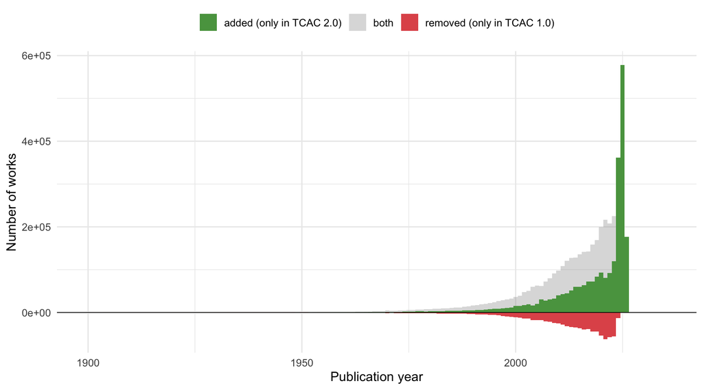

Figure 1

```r
ys <- cmp$yearly_status |>
  tidyr::pivot_wider(
    names_from = status,
    values_from = n,
    values_fill = 0L
  ) |>
  dplyr::rename(
    removed = `removed (only in TCAC 1.0)`,
    both = `both`,
    added = `added (only in TCAC 2.0)`
  ) |>
  dplyr::mutate(removed_neg = -removed)

ggplot2::ggplot(ys, ggplot2::aes(x = publication_year)) +
  ggplot2::geom_col(
    ggplot2::aes(y = both, fill = "both"),
    width = 1,
    alpha = 0.35
  ) +
  ggplot2::geom_col(
    ggplot2::aes(y = added, fill = "added (only in TCAC 2.0)"),
    width = 1
  ) +
  ggplot2::geom_col(
    ggplot2::aes(y = removed_neg, fill = "removed (only in TCAC 1.0)"),
    width = 1
  ) +
  ggplot2::geom_hline(yintercept = 0, colour = "black", linewidth = 0.3) +
  ggplot2::scale_fill_manual(
    name = NULL,
    breaks = c(
      "added (only in TCAC 2.0)",
      "both",
      "removed (only in TCAC 1.0)"
    ),
    values = c(
      "added (only in TCAC 2.0)" = "#59A14F",
      "both" = "#999999",
      "removed (only in TCAC 1.0)" = "#E15759"
    )
  ) +
  ggplot2::scale_y_continuous(labels = \(x) format(abs(x), big.mark = ",")) +
  ggplot2::labs(
    x = "Publication year",
    y = "Number of works"
  ) +
  ggplot2::theme_minimal(base_size = 12) +
  ggplot2::theme(legend.position = "top")
```

```r
cmp$yearly_status |>
  dplyr::summarise(n = sum(n), .by = status) |>
  dplyr::mutate(`%` = round(100 * n / sum(n), 2)) |>
  knitr::kable(
    format.args = list(big.mark = ","),
    caption = sprintf(
      "Aggregate composition of the corpus change. TCAC 1.0: %s works; TCAC 2.0: %s works.",
      format(cmp$n_tcac10, big.mark = ","),
      format(cmp$n_tcac20, big.mark = ",")
    )
  )
```

Table 3: Aggregate composition of the corpus change. TCAC 1.0: 4,178,134 works; TCAC 2.0: 5,771,209 works.

| status | n | % |
| --- | --- | --- |
| added (only in TCAC 2.0) | 2,466,482 | 37.15 |
| both | 3,278,534 | 49.38 |
| removed (only in TCAC 1.0) | 894,749 | 13.48 |